Krzysztof Ślot

Uczenie nienadzorowane - materiały do wykładu

# Redukcja wymiarowości danych

Obiekty świata rzeczywistego są reprezentowane jako punkty w wielowymiarowych przestrzeniach cech, wyznaczonych przez złożoną strukturę fizycznych systemów akwizycji danych (obrazów, dźwięku).

Redukcja wymiarowości danych to operacja pozwalająca na uproszczenie oryginalnej reprezentacji scen, pozwalająca na dokonanie ich efektywnej analizy dzięki pozostawieniu tego, co w danych jest najistotniejsze (z punktu widzenia konkretnego celu analizy). Taki proces jest naturalny dla biologii - również my w taki sposób upraszczamy docierające do nas dane.

Redukcja wymiarowości jest możliwa dzięki temu, że przestrzenie wielkowymiarowe są wypełnione próbkami skrajnie niejednorodnie: większa ich część nie zawiera próbek (równomierne wypełnienie przestrzeni ma miejsce tylko wtedy, gdy komponenty próbek stanowią szum o rozkładzie jednorodnym). W związku z tym, uprawnione jest założenie, że próbki odpowiadające danym rzeczywistym leżą w 'mniejszych' podprzestrzeniach i zwykle, wokół skomplikowanych, pofałdowanych powierzchni (ang. manifold) w tych podprzestrzeniach. Taka pofałdowana powierzchnia odpowiada typowej zmienności występującej wśród obiektów świata rzeczywistego - są one do siebie podobne w ramach podobnych kategorii i różne w obrębie różnych, chociaż te różnice nie są fundamentalne (wygląd kota nie różni się zasadniczo od wyglądu psa, który z kolei nie różni się istotnie od wyglądu konia itp.). W konsekwencji, redukcja może być postrzegana jako próba poszukiwania podprzestrzeni o minimalnej wymiarowości niezbędnej do zachowania istotnych dla osiągniecia założonego celu informacji (lub identyfikacji pofałdowanej powierzchni).

## Metody liniowe

### Analiza składowych głównych - PCA

Metoda PCA (Principal Component Analysis) redukcji liczby cech opisujących obiektym została wcześniej wyjaśniona (wykład SwAD), jako liniowa transformacja cech tworzących oryginalne wektory próbek $\mathbf{x}= [x_1 .... x_D]$, czyli budowa nowych cech $\xi^k$: \begin{equation} \xi_k = \sum_{i=1}^n w^k_i x_i = \mathbf{x}^T \mathbf{w}^k \end{equation} w której kryterium wyboru komponentów mieszaniny (wag $w^k_i$) cech oryginalnych było dążenie do zapewnienia maksymalnej wariancji rzutów próbek na kierunki nowej przestrzeni: \begin{equation} \mathbf{w}^k = \arg \max_\mathbf{v} E(\xi - \mu_\xi)^2 = \arg \max_\mathbf{v} E(\mathbf{v}^T\mathbf{x} - \mu_{\mathbf{v}^T\mathbf{x}})^2 \end{equation} Uwzględnienie ograniczenia, jakim jest wymaganie stałej długości wektorów, na które rzutujemy (np. $\mathbf{v}^T\mathbf{v}=1$) prowadzi do problemu własnego: \begin{equation} \mathbf{C} \mathbf{v} = \lambda \mathbf{v} \end{equation} którego rozwiązanie to zbiór wektorów własnych, odpowiadających maksymalnym wartościom własnym ($\lambda_1 ... \lambda_d$, $d<<D$) macierzy kowariancji próbek ($\mathbf{C}$). Redukcja wymiarowości to rzutowanie oryginalnych wektorów na znalezione kierunki: \begin{equation} \boldsymbol{\xi} = \mathbf{W}^T \mathbf{x} = \left[ \mathbf{w}_1, \mathbf{w}_2, ... , \mathbf{w}_d \right]^T \mathbf{x} \end{equation}

Kryterium wyboru zredukowanej przestrzeni cech: maksymalizację rozrzutu wartości rzutów próbek, można wyrazić w innej formie, która lepiej odpowiada przedstawionej wcześniej perspektywie poszukiwania podprzestrzeni $\mathcal{R}^d \in \mathcal{R}^D$ 'zawierającej' próbki. Zauważmy, że maksymalizacja długości rzutu próbki na poszukiwany kierunek $\mathbf{v}$, wyrażanej przez iloczyn skalarny: \begin{equation} \mathbf{v}^T\mathbf{v} = | \mathbf{v}| |\mathbf{x}| \cos(\mathbf{v},\mathbf{x}) \end{equation} jest równoważna minimalizacji odległości próbki od linii wyznaczanej przez ten wektor: \begin{equation} d(\mathbf{v},\mathbf{x}) = | \mathbf{v}| |\mathbf{x}| \sin(\mathbf{v},\mathbf{x}) \end{equation}

W efekcie, pozwala to na interpretację wyniku analizy PCA jako poszukiwania podprzestrzeni, która minimalizuje błąd 'modelowania' rozkładu za pomocą mniejszej liczby wymiarów. Przykładowo, zakładając że szukamy przestrzeni $\mathcal{R}^2$ dla próbek określonych w przestrzeni $\mathcal{R}^3$, wynikiem jest znalezienie płaszczyzny o położeniu zapewniającym minimalizację odległości oryginalnych próbek od jej powierzchni.

```python
import numpy as np
import matplotlib.pyplot as plt
from sklearn.datasets import make_classification
```

```python
# Dane - dwie cechy znaczące, jedna - losowa
X, labels = make_classification(n_features=3, n_informative=2, n_redundant=1)
```

```python
# transformacja pca
C = np.cov(X.T)
EVals, EVecs = np.linalg.eig(C)
idx = np.argsort(EVals)[::-1]
# Sortowanie wektorów własnych według malejących wartości własnych
EVecs = EVecs[idx]
# Określenie powierzchni najlepiej 'dopasowanej' do rozkładu próbek
# Wektor normalny powierzchni - iloczyn wektorowy EVec0 i EVec1
V = np.cross(EVecs[:,0], EVecs[:,1])
```

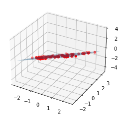

```python
# wizualizacja
fig = plt.figure()
ax = fig.add_subplot(projection='3d')
# próbki w przestrzeni 3D
ax.scatter(X[:,0],X[:,1], X[:,2], color='red')
# Zredukowana przestrzeń (2D) - płaszczyzna wyznaczona przez EVecs 0 i 1
n = 50 # liczba punktów siatki dla wizualizacji płaszczyzny
xx, yy = np.meshgrid(np.linspace(np.min(X[:,0]),np.max(X[:,0]),n),
                     np.linspace(np.min(X[:,1]),np.max(X[:,1]),n))
z = (- xx*V[0] - yy*V[1])/V[2] # wyznaczenie wartości z zgodnie z równaniem płaszczyzny o parametrach w V
# plaszczyzna 'półprzezroczysta'
ax.plot_surface(xx, yy, z, alpha=0.5)
```

### Skalowanie wielowymiarowe (Multidimensional Scaling - MDS)

Celem metody MDS jest redukcja wymiarowości przestrzeni cech, możliwie najlepiej zachowująca wzajemne odległości między próbkami. Narzucającym się zastosowaniem tej metody jest wizualizacja rozkładów próbek wielowymiarowych, które po przekształceniu do przestrzeni $\mathcal{R}^2$ lub $\mathcal{R}^3$ stają się możliwe do jakościowej analizy pod kątem na przykład oceny możliwości separacji lub występowania skupień.

Kryterium wyboru transformacji przestrzeni w MDS ( $f(\mathbf{x})$) jest najlepsze możliwe zachowanie wzajemnych odległości, czyli minimalizacja wyrażenia:

\begin{equation} J = \sum_i \sum_j || l(\mathbf{x}_i, \mathbf{x}_j) - l(f(\mathbf{x}_i), l(\mathbf{x}_j) ) || \end{equation}

gdzie $l(.)$ i $||.||$ oznaczają odległość (różne symbole oznaczają możliwość użycia różnych miar), a $f(.)$ przekształca próbki z przestrzeni $D$-wymiarowej do $d$-wymiarowej, gdzie $d<<D$.

Znalezienie odpowiedniej transformacji jest dokonywane dzięki zastosowaniu pomysłowego sposobu, wykorzystującego związek między odległościami a iloczynami skalarnymi wektorów. Odległość $L^2_2$ (kwadrat odległości Euklidesa) między wektorami $\mathbf{u}$ i $\mathbf{v}$ to: \begin{equation} L^2_2(\mathbf{u},\mathbf{v}) = ||\mathbf{u}||^2 + ||\mathbf{v}||^2 - 2 \mathbf{u}^T\mathbf{v} \end{equation}

Minimalizacja odległości to maksymalizacja iloczynu skalarnego (podobieństwa).

Załóżmy, że macierz odległości między próbkami to $\mathbf{L}$:

\begin{equation} \mathbf{L} = \left[ \begin{array}{cccc} 0 & L^2_2(\mathbf{x}_1,\mathbf{x}_2) & \ldots & L^2_2(\mathbf{x}_1,\mathbf{x}_n) \\ L^2_2(\mathbf{x}_2,\mathbf{x}_1) & 0 & \ldots & L^2_2(\mathbf{x}_2,\mathbf{x}_n) \\ & & \vdots & & \\ L^2_2(\mathbf{x}_n,\mathbf{x}_1) & L^2_2(\mathbf{x}_n,\mathbf{x}_n) & \ldots & 0 \end{array} \right] \end{equation}

oraz, że wprowadamy macierz $\mathbf{B}$, będącą macierzą iloczynów skalarnych między wszystkimi próbkami (nazywaną macierzą Grama):

\begin{equation} \mathbf{B} = \mathbf{X}^T \mathbf{X} = \left[ \begin{array}{cccccc} \mathbf{x}_1^T\mathbf{x}_1 & \mathbf{x}_1^T\mathbf{x}_2 & \ldots & \ldots & \ldots & \mathbf{x}_1^T\mathbf{x}_n\\ \mathbf{x}_2^T\mathbf{x}_1 & \mathbf{x}_2^T\mathbf{x}_2 & \ldots & \ldots & \ldots & \mathbf{x}_2^T\mathbf{x}_n\\ & & & \vdots & & \\ \mathbf{x}_n^T\mathbf{x}_1 & \mathbf{x}_n^T\mathbf{x}_2 & \ldots & \ldots & \ldots & \mathbf{x}_n^T\mathbf{x}_n\\ \end{array} \right] \end{equation}

Cel transformacji to redukcja wymiarowości zapewniająca najmniejsze możliwe różnice między odległościami w przestrzeni oryginalnej i poszukiwanej lub alternatywnie, możliwie najmniejsze różnice między wartościami odpowiednich iloczynów skalarnych próbek oryginalnych i przerzutowanych. W tym drugim ujęciu, celem jest znalezienie nowych wektorów $\mathbf{Y}_{d}$, $d<<D$ takich, że macierz ich iloczynów skalarnych $\mathbf{Y}^T \mathbf{Y}$ jest możliwie najbliższa macierzy $\mathbf{B}$. Zauważmy, że aproksymacja macierzy z użyciem kolejnych przybliżeń jest istotą analizy spektralnej, co oznacza, że jej użycie jest narzucającym się podejściem. Dekopmpozycja macierzy $\mathbf{B}$ względem wektorów i wartości własnych może być zapisana jako:

\begin{equation} \mathbf{B} = \mathbf{U} \boldsymbol{\Lambda} \mathbf{U}^T \end{equation}

gdzie $\boldsymbol{\Lambda}$ to diagonalna macierz wartości własnych a $\mathbf{U}$ - macierz wektorów własnych. Zakładając, że wartości własne są uporządkowane w kolejności malejącej, minimalne odstępstwa od macierzy $\mathbf{B}$ zapewni eliminacja $D-d$ wektorów własnych, odpowiadających najmniejszym wartościom własnym. Ponieważ $\mathbf{B} = \mathbf{X}^T\mathbf{X}$, można zauważyć, że:

\begin{equation} \mathbf{X}^T\mathbf{X} = (\mathbf{U} \boldsymbol{\Lambda}^{1/2}) (\boldsymbol{\Lambda}^{1/2} \mathbf{U}^T) \end{equation}

a więc:

\begin{equation} \mathbf{X}_{D \times n} = \boldsymbol{\Lambda}^{1/2}_{D \times D} \mathbf{U}^T_{D \times n} \end{equation}

Usunięcie $d-D$ najmniejszych wartości własnych, czyli wstawienie tam zer jest równoważne redukcji rozmiaru macierzy $\boldsymbol{\Lambda}^{1/2}$ i $\mathbf{U}$ do rozmiarów $d \times d$ i $n \ times d$ (ostanie $D-d$ wierszy powyższego wyrażenia stają się zerami), a więc poszukiwanym wektorem jest:

\begin{equation} \mathbf{Y}_{d \times n} = \boldsymbol{\Lambda}^{1/2}_{d \times d} \mathbf{U}^T_{d \times n} \end{equation}

W konsekwencji, redukcja wymiarowości to transformacja liniowa, wykorzystująca macierz złożoną z $d$-wektorów własnych, odpowiadających największym wartościom własnym macierzy Grama próbek oryginalnych.

#### Przykład

Wykorzystanie MDS do wizualizacji rozkładów próbek określonych w przestrzeniach o dużej wymiarowości dla przypadków: danych sztucznych (wygenerowanych rozkładów Gaussa) i danych rzeczywistych (z wybranych zbiorów z biblioteki torchvision).

```python
# Funkcja pomocnicza: wyznaczenie macierzy z próbkami z interesujących nas klas
# liczba próbek jest ograniczona do nx na klasę
def utworzMacierzProbek(X, Etykiety, wybraneEtykiety, nx):
    nClass = wybraneEtykiety.shape[0]
    for i in range(nClass):
        Xtmp = X[np.array(Etykiety)==wybraneEtykiety[i],...]
        Xtmp = Xtmp[:nx,...]
        if i==0:
            Probki = np.copy(Xtmp)
        else:
            Probki = np.concatenate((Probki,Xtmp), axis=0)
    # zamiana macierzy obrazów na wektory ('spłaszczenie')
    Probki = np.reshape(Probki,(Probki.shape[0],-1))
    Probki = Probki/np.max(Probki)
    return Probki
```

```python
# Transformacja MDS: utworzenie macierzy Grama, dekompozycja, wyznaczenie
# próbek w zredukowanej przestrzeni o wyniarze d
def transformacjaMDS(X,d):
    # utworzenie macierzy Grama
    B = np.dot(X,X.T)
    # dekompozycja spektralna
    EVals, EVecs = np.linalg.eigh(B)
    # posortowanie w porządku malejącym
    idx = np.argsort(EVals)
    EVals = EVals[idx[::-1]]
    EVecs = EVecs[:,idx[::-1]]
    # redukcja macierzy wartości i wektorów własnych do założonej wymiarowości
    U = EVecs[:,0:d]
    L = np.sqrt(EVals[:d])
    L = np.diag(L)  # eig zwraca wektor wartości własnych, trzeba go przekształcić w macierz
    # rzutowanie próbek do przestrzeni niskowymiarowej
    Y = np.dot(L,U.T)
    return Y
```

```python
def wizualizacja2D(Y,ClassLabels,nx, metoda):
    nClass = ClassLabels.shape[0]
    for i in range(nClass):
        plt.scatter(Y[0,i*nx:(i+1)*nx],Y[1,i*nx:(i+1)*nx], label=str(ClassLabels[i]))
    plt.legend()
    plt.title('Wizualizacja danych wielkowymiarowych - ' + metoda)
```

```
Wymiarowość przestrzeni oryginalnej D=30
```

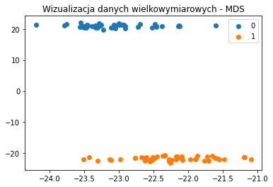

```python
# wizualizacja 2D/3D rozkładu próbek z użyciem MDS
# Dane sztuczne (proste klastry dwóch klas z przestrzeni wielowymiarowej)
import numpy as np
from sklearn.datasets import make_blobs
import matplotlib.pyplot as plt

lKlas = 2
ClassLabels = np.array([0,1])
D = 30
d = 2
# Generacja 100 próbek - pierwsze 50 z klasy A, drugie z klasy B (shuffle=False)
X, Etykiety = make_blobs(n_features=D, cluster_std=0.5, centers=lKlas, n_samples=100, shuffle=False)
print('Wymiarowość przestrzeni oryginalnej D=' + str(X.shape[1]))
Y = transformacjaMDS(X, d)
nx = X.shape[0]//2
wizualizacja2D(Y,ClassLabels,nx, 'MDS')
```

```
Wymiarowość przestrzeni oryginalnej D=784
```

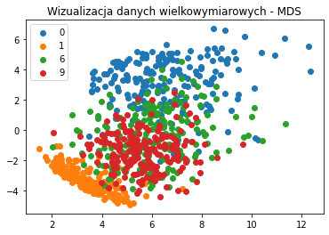

```python
# 2. Dane rzeczywiste - wybrane cyfry ze zbioru MNIST
from torchvision import datasets
# wczytanie danych
Dane = datasets.MNIST(root='data', train=False)
XX = Dane.data.numpy()
IndeksyKlas = Dane.targets.numpy()
MNIST_Labels = ['0','1','2','3','4','5','6','7','8','9']
# określenie parametrów
d=2
nx=200 # redukcja liczby rozważanych próbek da przyśpieszenia obliczeń
ClassLabels = np.array([0,1,6,9])
X = utworzMacierzProbek(XX, IndeksyKlas, ClassLabels, nx)
print('Wymiarowość przestrzeni oryginalnej D=' + str(X.shape[1]))
Y = transformacjaMDS(X, d)
wizualizacja2D(Y,ClassLabels,nx, 'MDS')
```

### Rekonstrukcja próbek z użyciem MDS

Załóżmy, że dana jest wyłącznie macierz odległości między obiektami (np. miastami) i nie znamy ich położeń (np. wsp. geograficznych). Problem, który chcielibyśmy rozwiązać to znalezienie wzajemnego położenia tych obiektów, a więc identyfikacja macierzy próbek. Ponieważ macierz odległości zawiera informację analogiczną do informacji zawartej w macierzy Grama, która powstaje na podstawie macierzy próbek (jej elementy to iloczyny skalarne, oceniające podobieństwa między próbkami), należy spodziewać się, że zadanie to powinno być możliwe do wykonania.

Załóżmy, że nieznane próbki, określone w przestrzeni $\mathcal{R}^D$, są umieszczone w macierzy $\mathbf{X}$:

\begin{equation} \mathbf{X} = \left[ \begin{array}{cccc} x_{1,1} & \ldots & \cdots & x_{1,D} \\ & \vdots & \vdots & \\ x_{i,1} & \ldots & x_{i,j} & \ldots \\ & \vdots & \vdots & \\ x_{n,1} & \ldots & \cdots & x_{n,D} \end{array} \right] \end{equation}

Macierz Grama $\mathbf{B} = \mathbf{X}^T \mathbf{X}$ zawiera iloczyny skalarne próbek $\mathbf{x}_i \in \mathbf{X}$:

\begin{equation} \mathbf{B} = \left[ \begin{array}{cccc} b_{1,1} & \ldots & \cdots & b_{1,n} \\ & \vdots & \vdots & \\ b_{i,1} & \ldots & b_{i,j} & \ldots \\ & \vdots & \vdots & \\ b_{n,1} & \ldots & \cdots & b_{n,n} \end{array} \right] = \left[ \begin{array}{cccc} \mathbf{x}_1^T \mathbf{x}_1 & \ldots & \cdots & \mathbf{x}_1^T \mathbf{x}_n \\ & \vdots & \vdots & \\ \mathbf{x}_i^T \mathbf{x}_1 & \ldots & \mathbf{x}_i^T \mathbf{x}_j & \ldots \\ & \vdots & \vdots & \\ \mathbf{x}_n^T \mathbf{x}_1 & \ldots & \cdots & \mathbf{x}_n^T \mathbf{x}_n \end{array} \right] \end{equation}

Celem analizy jest identyfikacja elementów macierzy Grama na podstawie posiadanej macierzy odległości $\mathbf{L}$:

\begin{equation} \mathbf{L} = \left[ \begin{array}{cccc} l_{1,1}^2 & \ldots & \cdots & l_{1,n}^2 \\ & \vdots & \vdots & \\ l_{i,1}^2 & \ldots & l_{i,j}^2 & \ldots \\ & \vdots & \vdots & \\ l_{n,1}^2 & \ldots & \cdots & l_{n,n}^2 \end{array} \right] \end{equation}

Element macierzy odległości $l_{i,j}^2$ w wierzu $i$ i kolumnie $j$, czyli kwadrat odległości między próbkami $\mathbf{x}_i$ i $\mathbf{x}_j$ to:

\begin{equation} l_{i,j}^2 = || \mathbf{x}_i - \mathbf{x}_j||^2_2 = \mathbf{x}_i \mathbf{x}_i + \mathbf{x}_j \mathbf{x}_j - 2\mathbf{x}_i \mathbf{x}_j = b_{ii} + b_{jj} - 2b_{ij} \end{equation}

Jednoznaczna identyfikacja wartości elementów próbek wymaga wprowadzenia dodatkowego założenia (macierz odległości daje nam informacje o względnych położeniach próbek). Jeżeli założymy, że próbki są wycentrowane (tzn. ich średnia wartość wynosi 0), wtedy wprowadzamy informację niezbędną dla możliwości jednoznacznego określenia ich współrzędnych. Wycentrowanie próbek oznacza, że suma elementów dla każdego wiersza macierzy próbek $\mathbf{X}$ wynosi 0:

\begin{equation} \forall{i} : \sum_{j=1}^n x_{ij}=0 \end{equation}

Korzystając z tej właściwości, można zauważyć, że suma elementów macierzy Grama w dowolnym wierszu (lub dowolnej kolumnie) jest równa zeru:

\begin{equation} \sum_{j=1}^n b_{ij} = \sum_j \mathbf{x}_{i}^T \mathbf{x}_{i} = \sum_{j=1}^n \sum_{k=1}^D x_{i,k} x_{j,k} = \sum_{k=1}^D x_{i,k} \sum_{j=1}^n x_{j,k} = \sum_{k=1}^D x_{i,k} \cdot 0 = 0 \end{equation}

Właściwość ta pozwala na proste wyznaczenie wartości elementów macierzy Grama w funkcji elementów macierzy odległości. Rozważmy sumy elementów macierzy odległości wzdłuż kolumn i wzdłuż wierszy:

\begin{equation} \sum_{j=1}^n l_{ij}^2 = \sum_{j=1}^n \left( b_{ii} + b_{jj} - 2b_{ij} \right) = \sum_{j=1}^n b_{ii} + \sum_{j=1}^n b_{jj} -2 \sum_{j=1}^n b_{ij} = n b_{ii} + T(\mathbf{B}) - 2\cdot 0 = n b_{ii} + T(\mathbf{B}) \end{equation}\begin{equation} \sum_{i=1}^n l_{ij}^2 = \sum_{i=1}^n \left( b_{ii} + b_{jj} - 2b_{ij} \right) = \sum_{i=1}^n b_{ii} + \sum_{i=1}^n b_{jj} -2 \sum_{i=1}^n b_{ij} = T(\mathbf{B}) + n b_{jj} - 2\cdot 0 = n b_{jj} + T(\mathbf{B}) \end{equation}

Symbol $T(.)$ to ślad macierzy (suma wszystkich elementów diagonalnych). Powyższe dwa wzory pozwalają na wyznaczenie diagonalnych elementów macierzy Grama, pod warunkiem, że znany jest jej ślad $T(\mathbf{B})$. Ślad można obliczyć, korzystając z faktu, że suma wszystkich elementów macierzy odległości to:

\begin{equation} \sum_{i=1}^n \sum_{j=1}^n l_{ij}^2 = \sum_{i=1}^n \sum_{j=1}^n b_{ii} + \sum_{i=1}^n \sum_{j=1}^n b_{jj} -2 \sum_{i=1}^n \sum_{j=1}^n b_{ij} = \sum_{j=1}^n T(\mathbf{B}) + \sum_{i=1}^n T(\mathbf{B}) - 2\cdot 0 \end{equation}

a więc:

\begin{equation} T(\mathbf{B}) = \frac{1}{2n} \sum_{i=1}^n \sum_{j=1}^n l_{ij}^2 \end{equation}

Wreszcie, znając ślad i wartości dowolnego elementu diagonalnego macierzy Grama, można obliczyć jej dowolny pozadiagonalny element $b_{ij}$, korzystając z wcześniej przedstawionej zależności:

\begin{equation} l_{i,j}^2 = b_{ii} + b_{jj} - 2b_{ij} \rightarrow b_{ij} = \frac{1}{2} \left( b_{ii} + b_{jj} - l_{i,j}^2 \right) \end{equation}

Możliwość rekonstrukcji rozmieszczenia punktów (wektorów) na podstawie informacji o ich wzajemnych odległościach stanowi przydatny przykład eksploracji danych w przypadku, gdy dysponujemy tylko ograniczoną wiedzą. Okazuje się jednak, że przedstawiona metoda dostarcza niezbędnego elementu niewzwykle efektywnej procedury nieliniowej redukcji wymiarowości problemu - metody Isomap, omówionej w dalszej części dokumentu.

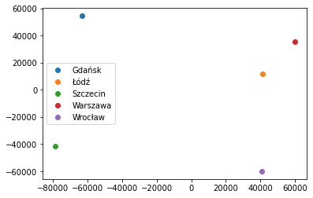

```python
# Rekonstrukcja 2D lokalizacji miast na podstawie wiedzy o ich odległościach
Miasta = ['Gdańsk', 'Łódź', 'Szczecin', 'Warszawa', 'Wrocław']
# Macierz odległości
L = np.array([[0,0,0,0,0], [293,0,0,0,0], [287,380,0,0,0],
              [344, 130, 454, 0,0], [464, 183, 309,302,0]])
L = np.square(L + L.T)

n = L.shape[0]
# obliczenie macierzy Grama
# 1. Trace = sum_i sum_j l_ii / 2n
T = np.sum(L)/(2*n)
# elementy diagonalne: bii = (\sum_j lij -T )/n
Diag = (np.sum(L, axis=0) - T)/n
# elementy pozostałe: bij = 0.5(bii+bjj - lij)
Diag_H = np.dot(Diag.reshape((n,-1)),np.ones((1,n)))
Diag_V = Diag_H.T
B = 0.5*(Diag_H + Diag_V - L)

# obliczenie wektorów
d=2
Y = transformacjaMDS(B, d)
# wizualizacja wyniku
plt.figure()
for i in range(n):
    plt.scatter(Y[0,i], Y[1,i], label=Miasta[i])
plt.legend()

# UWAGA - położenia punktów są wyznaczone z dokładnością do obrotu układu względem punktu (0,0)!
```

## Metody nieliniowe

### Isomap

Metoda Isomap (Isometric Mapping) stanowi sposób budowy przestrzeni przybliżających pofałdowane wielowymiarowe powierzchnie, na których rozmieszczone są rzeczywiste próbki. Metoda stanowi powiązanie grafowej reprezentacji relacji między próbkami i skalowania wielowymiarowego. Odkrywanie obszarów przestrzeni, które są w ciągły sposób wypełniane próbkami następuje poprzez budowanie grafu, w którym wiązane są sąsiadujące ze sobą obiekty. Nieliniowa, pofałdowana hiperpowierzchnia jest więc przybliżana jako zbiór lokalnych 'łatek', w obrębie których poprawnie można oceniać podobieństwo z użyciem geometrii Euklidesa. Podobieństwa (a więc i odległości) między punktami położonymi w przestrzeni dalej od siebie, są określane iteracyjnie, w poddziedzinach powiązanych z kolejnymi łatkami.

W metodzie ISOMAP odległości między punktami to tzw. odległości geodezyjne. Pojęcie odległości geodezyjnej ma genezę w określaniu odległości między punktami na Ziemi, gdzie konieczne jest uwzględnianie zagięcia powierzchni. Odległości geodezyjne między próbkami są obliczane jako najmniejsza odległość, przebiegająca między połączonymi ze sobą węzłami grafu. Ponieważ istnieje wiele możliwych kombinacji ścieżek w grafie, znajdywanie minimalnej odległości jest kosztowne obliczeniowo (choć z uwagi na rzadką strukturę grafu, może być znacznie przyśpieszane) i jest realizowane za pomocą algorytmu Dijkstry lub Floyda.

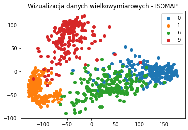

```python
# -------------------------  ISOMAP
'''
    Metodyka:
        1. Zbuduj dla próbek graf sąsiedztwa i określ affinity matrix
        2. Określ odległości geodezyjne dla próbek na podstawie AM
        3. Dokonaj estymacji macierzy X
        4. Dokonaj redukcji wymiarowości
'''
from sklearn.neighbors import kneighbors_graph
from scipy.sparse.csgraph import floyd_warshall

ClassLabels = np.array([0,1,6,9])
# Dane wejściowe - cyfry MNIST - zawarte są w macierzy XX
WybraneProbki = utworzMacierzProbek(XX, IndeksyKlas, ClassLabels, nx)

# obliczenie macierzy połączeń (dla próbki 'i' najbliżsi sąsiedzi to 'j')
l_sasiadow = 9
G = kneighbors_graph(WybraneProbki, n_neighbors=l_sasiadow, mode='distance')
# Obliczenie macierzy odległości (znalezienie ścieżek o minimalnym zakumulowanym koszcie)
dist_matrix = floyd_warshall(csgraph=G, directed=False)
# wyznaczenie macierzy Grama próbek - B
d=2
# macierz centrująca o rozmiarze nxn
n = dist_matrix.shape[0]
H = (np.identity(n)-np.ones((n,n))/n)
# można wykazać, że macierz Grama można obliczyć z macierzy odległości jako: B = -HDH/2
B2 = -0.5*(H@dist_matrix)@H
Y2 = transformacjaMDS(B2, d)

wizualizacja2D(Y2,ClassLabels,nx, 'ISOMAP')
```

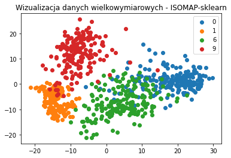

```python
# ----------------- ISOMAP z pakietu sklearn
#from sklearn.datasets import load_digits
from sklearn.manifold import Isomap
#X, _ = load_digits(return_X_y=True)
#>>> X.shape
embedding = Isomap(n_components=2, n_neighbors=l_sasiadow)
X_transformed = embedding.fit_transform(WybraneProbki)

wizualizacja2D(X_transformed.T, ClassLabels, nx, 'ISOMAP-sklearn')
```

### Spektralna redukcja wymiarowości (Spectral Embedding, Laplacian Eigenmaps)

Metoda 'Map własnych' Laplasjanu (grafu) jest z punktu widzenia metodyki postępowania, bardzo blisko powiązana z omówioną wcześniej metodą klasteryzacji spektralnej. Rozważanym celem redukcji wymiarowości jest zachowanie odległości między próbkami po ich transformacji do przestrzeni niskowymiarowej, a więc zapewnienie, by dla każdej pary rzutów $\mathbf{Y}_i = g(\mathbf{X}_i)$ i $\mathbf{Y}_j = g(\mathbf{X}_j)$, gdzie $\mathbf{Y}_i, \mathbf{Y}_j \in \mathcal{R}^d$, $\mathbf{X}_i, \mathbf{X}_j \in \mathcal{R}^D$, $d<<D$, zachodziło:

\begin{equation} \sum_{i,j} \left| \left| l(\mathbf{Y}_i, \mathbf{Y}_j) - l( \mathbf{X}_i, \mathbf{X}_j) \right| \right| \rightarrow \min \end{equation}

gdzie $l(.)$ i $||.||$ oznaczają normy.

Jeżeli dla zbioru próbek zbudowany zostanie graf sąsiedztwa, w którym węzły połączone są jedynie z najbliższymi sąsiadami, to przedstawiony powyżej warunek można przedstawić jako:

\begin{equation} J(\{ \mathbf{Y}_k \}) = \sum_{i,j} ||\mathbf{Y}_i - \mathbf{Y}_j)|| w_{i,j} \rightarrow \min \end{equation}

gdzie $w_{i,j}$ to podobieństwa między próbkami $\mathbf{X}_i, \mathbf{X}_j$. Zasadność wyrażenia wynika z przyjętego celu transformacji: zachowania podobieństw wyłącznie w skali lokalnej. Komponenty odległości między odległymi próbkami w ogóle nie są brane pod uwagę, a celem staje się jedynie zachowanie lokalnej zgodności rozmieszczenia próbek oryginalnych i przerzutowanych (jeżeli były oryginalnie bliżej, czyli $w_{i,j}$ było duże, odległości rzutów powinny być małe i na odwrót).

Zauważmy, że jeśli próbki mają być rzutowane do przestrzeni jednowymiarowej, wtedy $\mathbf{Y}_i = y_i$, a funkcja kryterialna może być przedstawiona jako:

\begin{equation} J(\{ y_k \}) = \sum_{i,j} (y_i - y_j)^2 w_{i,j} \rightarrow \min \end{equation}

W efekcie, funkcja kryterialna staje się formalnie identyczna z funkcją utworzoną jako podstawa dla realizacji klasteryzacji spektralnej. Jedyna różnica to inny sens występujących w niej zmiennych: w SC poszukiwano wartości etykiet węzłów minimalizujących kryterium ($f(.)$), obecnie poszukujemy rzutów próbek oryginalnych $\mathbf{X}_i \rightarrow \mathbf{Y}_i = y_i$, które jak najlepiej zachowają oryginalne rozmieszczenie. Zauważmy, że interpretacja wyrażenia w nawiasie, to odległość w 1D między rzutami: aby dobrze odzwierciedlała odległości oryginalne, powinna być tym mniejsza, im podobieństwa oryginalne, reprezentowane przez wagi, są większe. W efekcie, celem procedury jest tak jak poprzednio, minimalizacja funkcji kryterialnej. Rozwiązaniem problemu jest, podobnie jak poprzednio, wektor własny macierzy Laplace'a grafu, odpowiadający drugiej najmniejszej wartości własnej. Komponenty wektora własnego stanowią współrzędne 1D próbek $\mathbf{Y}$.

Jeżeli celem jest poszukiwanie zredukowanej przestrzeni o wymiarze $d>1$, wtedy funkcja kryterialna przyjmuje postać:

\begin{equation} J = \sum_{i,j} ||\mathbf{Y}_i - \mathbf{Y}_j)|| w_{i,j} = \mathbf{Y}^T \mathbf{L} \mathbf{Y} \rightarrow \min \end{equation}

Rozwiązanie problemu jest identyczne jak poprzednio. Tym razem jednak, jeśli docelowy wymiar wektorów $\mathbf{Y}$ ma wynosić $d$, jako współrzędne próbek wybierane są elememty pierwszych $d$ wektorów własnych (nie licząc zerowego).

Problemem, który może sprawić, że przedstawiona procedura nie da spodziewanego wyniku, jest zróżnicowanie znaczenia próbek, wynikające ze zróżnicowanej struktury rozkładu próbek. Jeżeli próbka leży w obszarze dużego zagęszczenia, wagi (podobieństwa) do jej najbliższych sąsiadów będą duże, jeśli leży w obszarze słabo wypełnionym próbkami, wagi będą mniejsze. Aby zapewnić możliwość poprawnej rekonstrukcji struktury niezależnie od lokalnych zagęszczeń, należy przypisując węzłom grafu znaczenie odwrotnie proporcjonalne do ich rzędu, co można wyrazić jako normalizację długości wektorów:

\begin{equation} ||\mathbf{Y}_i||=\frac{1}{D_{ii}} \rightarrow \mathbf{Y}^T \mathbf{D} \mathbf{Y} = \mathbf{I} \end{equation}

gdzie $\mathbf{D}$ oznacza macierz rzędu a $\mathbf{I}$ jest macierzą jednostkową (jedynki na diagonalnej). W efekcie, problem redukcji wymiarowości przestrzeni staje się problemem optymalizacyjnym z ograniczeniem, o postaci:

\begin{equation} \min_{\mathbf{Y_k}} \mathbf{Y}^T \mathbf{L} \mathbf{Y}: \hspace{0.5cm} \mathbf{Y}^T \mathbf{D} \mathbf{Y} = \mathbf{I} \end{equation}

Korzystając z metody Lagrangea i obliczając pochodne, warunek osiągnięcia celu przyjmuje postać:

\begin{equation} \mathbf{L} \mathbf{Y} = \lambda \mathbf{D} \mathbf{Y} \end{equation}

Równanie to nazywa się 'uogólnionym problemem spektralnym' (Generalized Eigenvalue Problem) i występuje w technice równie często co równanie spektralne.

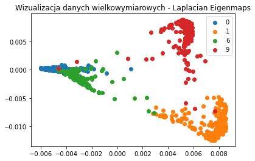

```python
from scipy.linalg import eigh

G2 = G.toarray()
AdjM = 0.5*(G2 + G2.T)
# obliczenie degree-matrix
D = np.diag(np.sum(AdjM, axis=1))
# Obliczennie macierzy Laplace'a
L = D - AdjM

# rozwiązanie uogólnionego problemu własnego: macierz rzędu (D) to normalizacja
# (jak w normalized SC) - cel to ujednolicić znaczenie wszystkich węzłów grafu
# nawet jeśli nie mają one bliskich sąsiadów, ich wzajemne lokalizacje powinny być
# zachowane
EVals, EVecs = eigh(L,b=D) #  np.linalg.eig(L)
idx = np.argsort(EVals) # kolejność od min do max
EVals = EVals[idx]
EVecs = EVecs[idx]
d=2
Y = EVecs[:,1:d+1].T
wizualizacja2D(Y, ClassLabels, nx, 'Laplacian Eigenmaps')
```

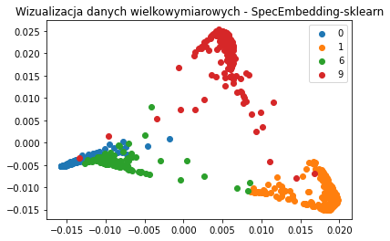

```python
# --------------------- Spectral Embedding - sklearn

from sklearn.manifold import SpectralEmbedding

sp_emb = SpectralEmbedding(n_components=2, n_neighbors=l_sasiadow)
Xtransformed_SE = sp_emb.fit_transform(WybraneProbki)

wizualizacja2D(Xtransformed_SE.T, ClassLabels, nx, 'SpecEmbedding-sklearn')
```

### Metoda Nystroma

Metoda redukcji Nystroma należy do najbardziej atrakcyjnych sposobów radzenia sobie z ogromnymi zbiorami danych, dla których inne podejścia (w ty, omówione wcześniej) są niemożliwe do wdrożenia z uwagi na złożoność obliczeniową.

### Metoda t-SNE

Założeniem, na którym zbudowane są przedstawione metody nieliniowej redukcji przestrzeni (reprezentatywne dla badań prowadzonych przed 2008), zmierzające do zachowania struktury rozmieszczenia próbek w przestrzeni, jest założenie ciągłości pofałdowanej podprzestrzeni, w której określone są próbki. Dzięki temu założeniu można oczekiwać poprawnych wyników oceny podobieństw na podstawie odległości definiowanych dla grafów, których węzły ulokowane są w rozważanej podprzestrzeni.

Okazuje się, że przedstawione założenie jest niekoniecznie spełnione (patrz wcześniejsze eksperymenty z obrazami cyfr) - próbki różnych kategorii mogą leżeć w osobnych, izolowanych od siebie pofałdowanych podprzestrzeniach. Dlatego też, podejścia mające u podstaw modelowanie próbek z użyciem grafów muszą być zastąpione innymi pomysłami, z których jednym z najskuteczniejszych stała się metoda t-SNE (t-Stochastic Nonlinear Embedding).